# Data Modification

Bill Perry

2018/03/14

## Dataframe wide to long and long to wide

I seem to always have to go back and read how to do this over and over so I am trying to get it down here so I can use this as a reference and others might find it helpful.

Wide format is how you would usually enter data in excel with treatment down the left had side or some other category and variables for that treatment along the top row. This if a fine way to enter data but is not often that useful in R and you need to switch it to long format. I will post examples soon

## Load libraries

```r
# One new package for summary stats
#install.packages("psych")

# load the libraries each time you restart R
library(tidyverse)
library(lubridate)
library(scales)
library(skimr)
library(janitor)
library(patchwork)
library(reshape2)
library(kableExtra)
```

## Read in file

So a lot of us have to deal with grades but you will get the idea of how this works with a simple dataframe and then we can go on.

```r
# read in the file
grades.df <- read_csv("data/grades.csv") %>%
  clean_names() %>%
  remove_empty(c("rows", "cols"))
glimpse(grades.df)
```

```
## Observations: 99
## Variables: 7
## $ student_id <chr> "john_doe_1", "john_doe_2", "john_doe_3", "john_doe...
## $ hw_1       <dbl> 25.14, 25.14, 25.14, 25.14, 24.81, 24.81, 24.81, 24...
## $ hw_2       <dbl> 28.87, 28.87, 28.87, 28.85, 28.85, 28.84, 28.84, 28...
## $ hw_3       <dbl> 25.96, 25.96, 25.96, 25.96, 25.96, 25.96, 25.96, 25...
## $ hw_4       <dbl> 23.94, 23.94, 23.94, 23.94, 23.94, 23.94, 23.94, 23...
## $ hw_5       <dbl> 24.32, 24.32, 24.32, 24.32, 24.32, 24.32, 24.32, 24...
## $ hw_6       <dbl> 31.18, 31.18, 31.09, 31.06, 31.06, 31.03, 31.00, 31...
```

## Wide format file

This file is something that we might hae entered the grades in and it is something we are used to doing in excel. That is not bad but it limits what we can do fast with the file.

```r
head(grades.df) %>%
  kable("html") %>%
  kable_styling(bootstrap_options = c("striped", "hover", "condensed"))
```

| student_id | hw_1 | hw_2 | hw_3 | hw_4 | hw_5 | hw_6 |
| --- | --- | --- | --- | --- | --- | --- |
| john_doe_1 | 25.14 | 28.87 | 25.96 | 23.94 | 24.32 | 31.18 |
| john_doe_2 | 25.14 | 28.87 | 25.96 | 23.94 | 24.32 | 31.18 |
| john_doe_3 | 25.14 | 28.87 | 25.96 | 23.94 | 24.32 | 31.09 |
| john_doe_4 | 25.14 | 28.85 | 25.96 | 23.94 | 24.32 | 31.06 |
| john_doe_5 | 24.81 | 28.85 | 25.96 | 23.94 | 24.32 | 31.06 |
| john_doe_6 | 24.81 | 28.84 | 25.96 | 23.94 | 24.32 | 31.03 |

### Graphing in wide format

So we want to make histograms of the grades and see what they are doing in each of the homeworks. We would have to make a plot for each of them. Ugggh… This is doable though and fine.

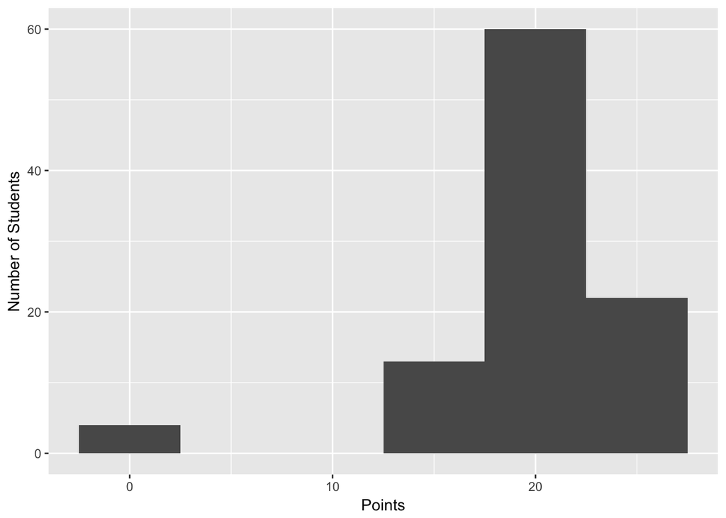

```r
grades.df %>% ggplot(aes(hw_1)) +
  geom_histogram(binwidth = 5 ) +
  scale_x_continuous(breaks=seq(0,100,10)) +
  labs(x="Points", y="Number of Students")
```

## Convert to *long* format

Note that it is a bit differnet now. you hae students going down the left, item which has each homework for each student and the grades on the right. Studnet 1 is listed 6 times for each of his 6 homeworks. Why on earh would we do this!!!!!?????

```r
grades_long.df <- grades.df %>%
  gather(item, grade, -student_id) %>%
  mutate(item = as.factor(item)) %>%
  arrange(student_id, item)


head(grades_long.df, n=10) %>%
  kable("html") %>%
  kable_styling(bootstrap_options = c("striped", "hover", "condensed"))
```

| student_id | item | grade |
| --- | --- | --- |
| john_doe_1 | hw_1 | 25.14 |
| john_doe_1 | hw_2 | 28.87 |
| john_doe_1 | hw_3 | 25.96 |
| john_doe_1 | hw_4 | 23.94 |
| john_doe_1 | hw_5 | 24.32 |
| john_doe_1 | hw_6 | 31.18 |
| john_doe_10 | hw_1 | 23.97 |
| john_doe_10 | hw_2 | 28.64 |
| john_doe_10 | hw_3 | 25.96 |
| john_doe_10 | hw_4 | 23.94 |

## Why *long* format

Well the reason you need this format is for several types of analyses and it also makes graphing and workign with the data easier. Here is an example to show all the graphs for eah homework in a quick way…  
Remember we can use filter and select to do things in ggplot with before the plot command too…

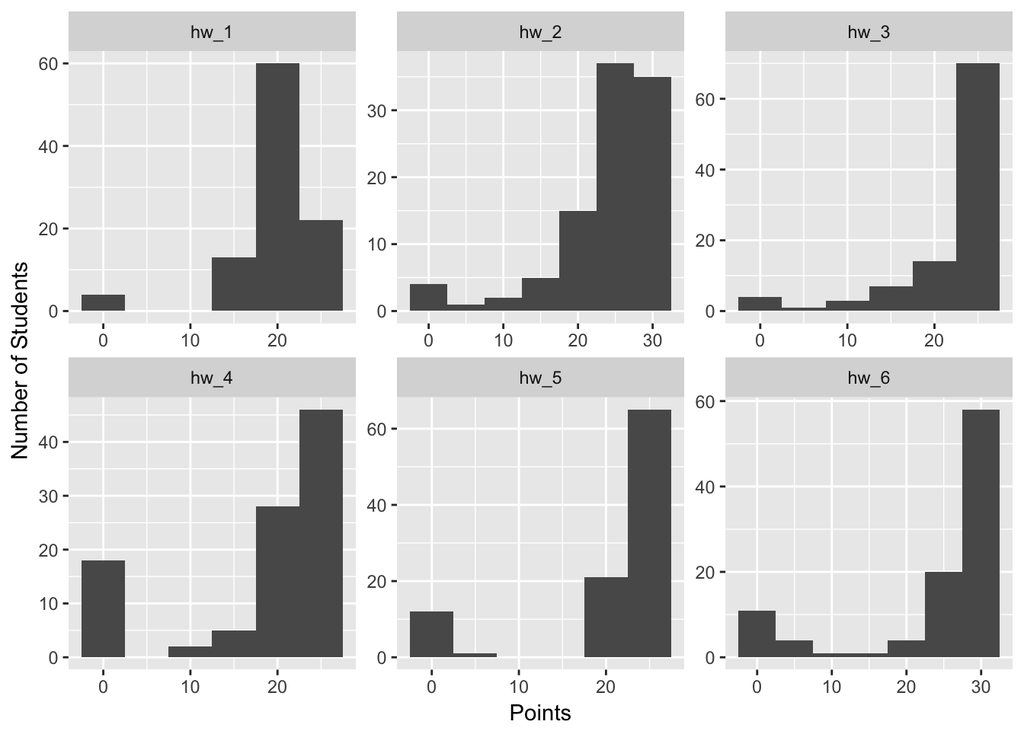

```r
grades_long.df %>%
  ggplot(aes(grade)) +
  geom_histogram(binwidth = 5 ) +
  scale_x_continuous(breaks=seq(0,100,10)) +
  labs(x="Points", y="Number of Students") +
  facet_wrap("item",  scales = "free")
```

Lets say you only wanted to show homeworks 1 - 3 in the above plot. How could you do this easily

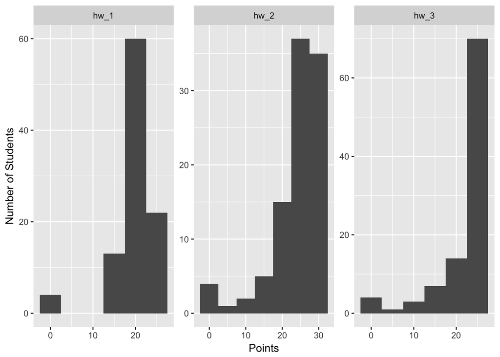

```r
grades_long.df %>% filter(item == "hw_1" |
                            item == "hw_2" |
                          item == "hw_3") %>%
  ggplot(aes(grade)) +
  geom_histogram(binwidth = 5 ) +
  scale_x_continuous(breaks=seq(0,100,10)) +
  labs(x="Points", y="Number of Students") +
  facet_wrap("item",  scales = "free")
```

```r
# read in the file
iris.df <- read_csv("data/iris.csv") %>%
  clean_names() %>%
  remove_empty(c("rows", "cols"))
glimpse(iris.df)
```

```
## Observations: 150
## Variables: 5
## $ sepal_length <dbl> 5.1, NA, 4.7, 4.6, 5.0, 5.4, 4.6, 5.0, 4.4, 4.9, ...
## $ sepal_width  <dbl> 3.5, 3.0, 3.2, 3.1, 3.6, 3.9, 3.4, 3.4, 2.9, 3.1,...
## $ petal_length <dbl> 1.4, 1.4, 1.3, 1.5, 1.4, 1.7, 1.4, 1.5, 1.4, 1.5,...
## $ petal_width  <dbl> 0.2, 0.2, 0.2, 0.2, 0.2, 0.4, 0.3, 0.2, 0.2, 0.1,...
## $ species      <chr> "setosa", "setosa", "setosa", "setosa", "setosa",...
```

```r
# this will add an index to the dataframe so you know what individual is which
iris.df <- iris.df %>% mutate(individual = row_number())
```

There are times that you need to switch back

```r
iris_long.df <- iris.df %>% gather(trait, measure, -species, - individual)
```

Using tidyr

```r
iris_wide.dff <- iris_long.df %>%
  spread(trait, measure)
```

## Spread and Unite

unite

```r
iris_unite.df <- iris.df %>%
  unite("ind_species", individual, species, sep="_")
```

separate

```r
iris_spread.df <- iris_unite.df %>%
  separate(ind_species, into=c("individual", "species"), sep="_")
```

```r
# read in the file
iris.df <- read_csv("data/iris.csv") %>%
  clean_names() %>%
  remove_empty(c("rows", "cols"))
glimpse(iris.df)
```

```
## Observations: 150
## Variables: 5
## $ sepal_length <dbl> 5.1, NA, 4.7, 4.6, 5.0, 5.4, 4.6, 5.0, 4.4, 4.9, ...
## $ sepal_width  <dbl> 3.5, 3.0, 3.2, 3.1, 3.6, 3.9, 3.4, 3.4, 2.9, 3.1,...
## $ petal_length <dbl> 1.4, 1.4, 1.3, 1.5, 1.4, 1.7, 1.4, 1.5, 1.4, 1.5,...
## $ petal_width  <dbl> 0.2, 0.2, 0.2, 0.2, 0.2, 0.4, 0.3, 0.2, 0.2, 0.1,...
## $ species      <chr> "setosa", "setosa", "setosa", "setosa", "setosa",...
```

## Add a unique identifier

```r
# this will add an index to the dataframe so you know what individual is which
iris.df <- iris.df %>% mutate(individual = row_number())
```

## now the idea of reformatting a dataframe

How to make a database into long format.

```r
iris_long.df <- iris.df %>% gather(trait, measure, -species, - individual)
```

## Reshape 2

Sometimes I use this and it might make more sense to some and does about the same thing.

```r
iris_long_reshape2.df <- iris.df %>%
                melt(
                     variable.name = "trait",
                     value.names = "meausre",
                     id.vars = c("species", "individual")
                     )
```

## Long to Wide format

Using tidyr

```r
iris_wide.dff <- iris_long.df %>%
  spread(trait, measure)
```

Using Reshape2

```r
iris_wide_reshape.dff <- iris_long.df %>%
  dcast(individual + species ~ trait, value.var = "measure")
```

## Spread and Unite

unite

```r
iris_unite.df <- iris.df %>%
  unite("ind_species", individual, species, sep="_")
```

separate

```r
iris_spread.df <- iris_unite.df %>%
  separate(ind_species, into=c("individual", "species"), sep="_")
```